# homework_3_Fan_Chisun

Chisun Fan

February 15, 2019

## 3.8.1 Exercises

*1.What is the problem with this plot? How could you improve it?*

*ggplot(data = mpg, mapping = aes(x = cty, y = hwy)) +* *geom_point()*

### Points are overlapped and not showing the complete data. Replace geom_point with geom_gitter will fix the overlapping issue and show every instance of the data set.

*2.What parameters to geom_jitter() control the amount of jittering?*

### width and height

*3. Compare and contrast geom_jitter() with geom_count().*

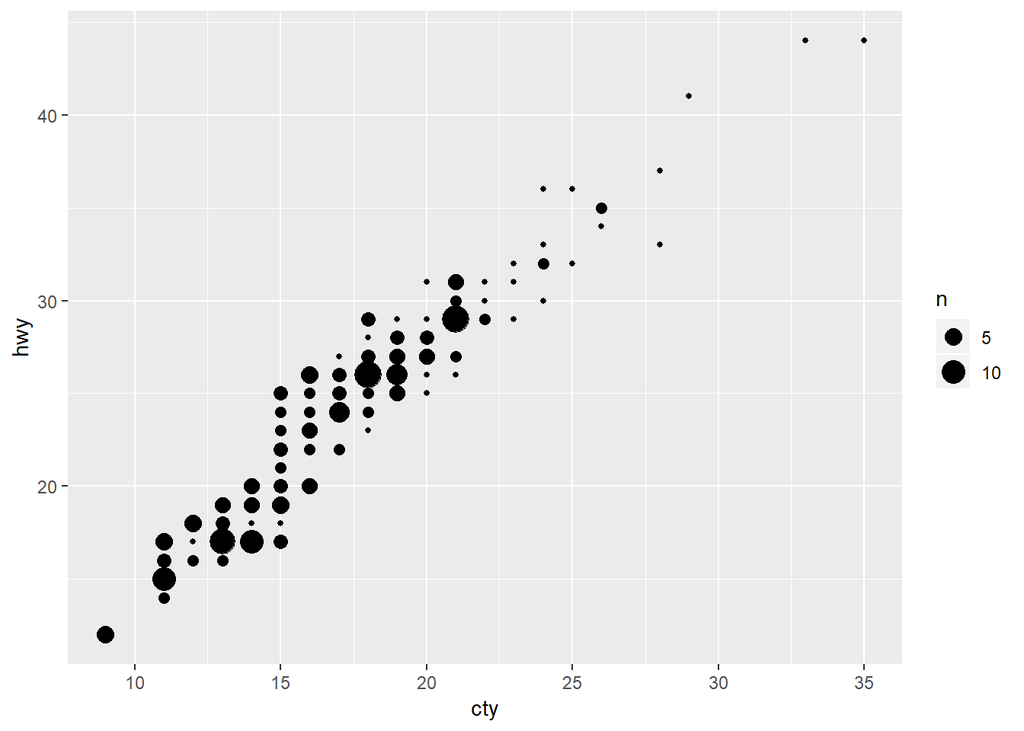

```r
library(tidyverse)
ggplot(data=mpg, mapping=aes(x=cty, y=hwy))+geom_count()
```

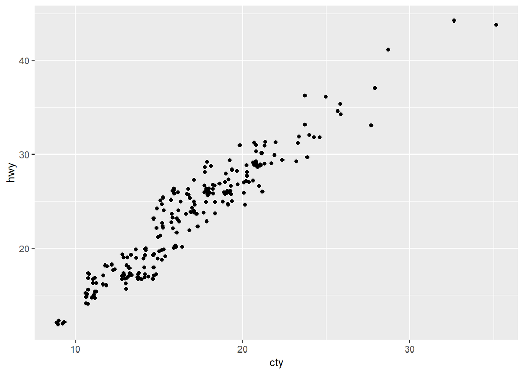

```r
ggplot(data=mpg, mapping=aes(x=cty, y=hwy))+geom_jitter()
```

### geom_jitter shows overlapping data by jittering while geom_count shows overlapping data by the size of the point.

*4.What’s the default position adjustment for geom_boxplot()? Create a visualisation of the mpg dataset that demonstrates it.*

### The default is “dodge2”

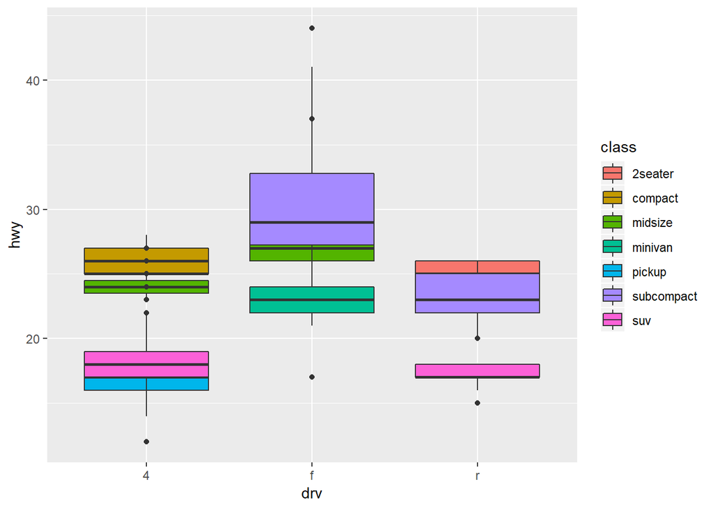

```r
ggplot(data=mpg, mapping=aes(x=drv, y=hwy, fill=class))+geom_boxplot(position="identity")
```

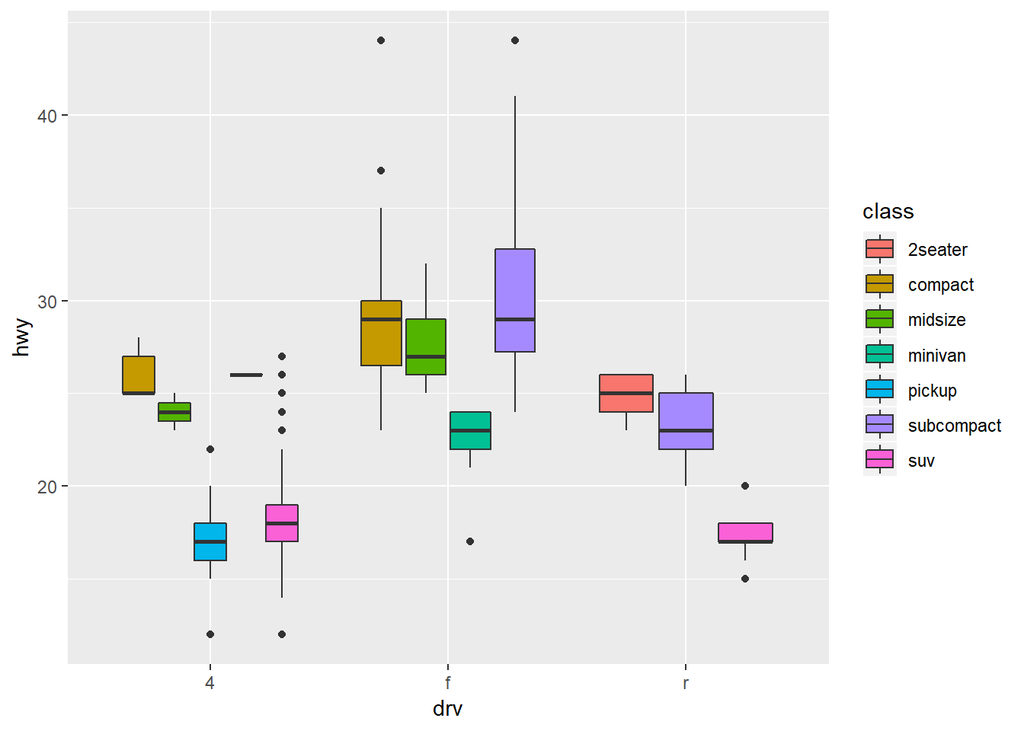

```r
ggplot(data=mpg, mapping=aes(x=drv, y=hwy, fill=class))+geom_boxplot()
```

## 3.9.1 Exercises

*2.What does labs() do? Read the documentation.*

### The labs() function interpret the graphic information using labels, titles, and other text so that the audience can understand the plot better.

*4.What does the plot below tell you about the relationship between city and highway mpg? Why is coord_fixed() important? What does geom_abline() do?*

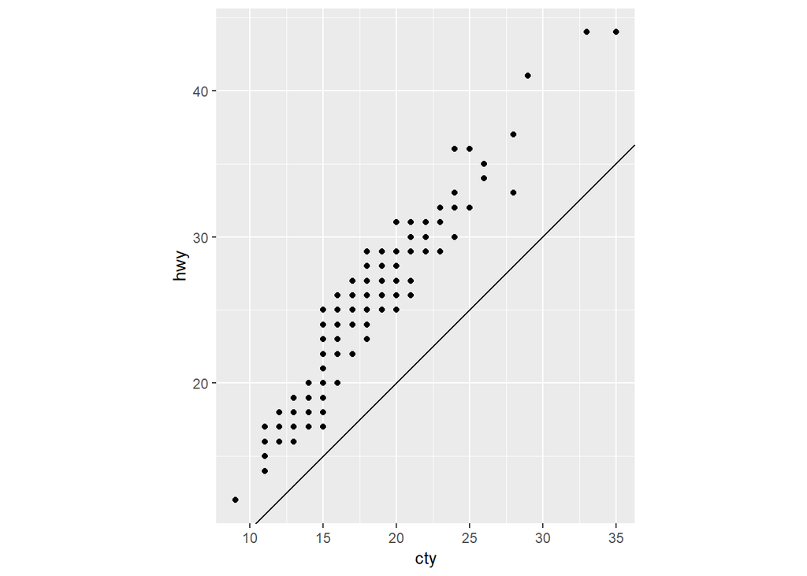

```r
ggplot(data = mpg, mapping = aes(x = cty, y = hwy)) +
  geom_point() +
  geom_abline() +
  coord_fixed()
```

## 4.4 Practice

*1.Why does this code not work?*

*my_variable <- 10*

*my_varıable*

*> Error in eval(expr, envir, enclos): object ‘my_varıable’ not found*

*Look carefully! (This may seem like an exercise in pointlessness, but training your brain to notice even the tiniest difference will pay off when programming.)*

### Don’t know. code executed just fine in my console sub-window.

```r
my_variable <- 10
my_variable
```

```
## [1] 10
```

*2.Tweak each of the following R commands so that they run correctly:*

library(tidyverse)

ggplot(data = mpg) + geom_point(mapping = aes(x = displ, y = hwy))

fliter(mpg, cyl = 8)

filter(diamond, carat > 3)

### first two does not have issues running.

### filter(mpg, cyl== 8)

### filter(diamonds, carat > 3)

## 5.2.4 Exercises

*1.Find all flights that*

*1.Had an arrival delay of two or more hours*

```r
library(nycflights13)
filter(flights, dep_delay >=120)
```

```
## # A tibble: 9,888 x 19
##     year month   day dep_time sched_dep_time dep_delay arr_time
##    <int> <int> <int>    <int>          <int>     <dbl>    <int>
##  1  2013     1     1      848           1835       853     1001
##  2  2013     1     1      957            733       144     1056
##  3  2013     1     1     1114            900       134     1447
##  4  2013     1     1     1540           1338       122     2020
##  5  2013     1     1     1815           1325       290     2120
##  6  2013     1     1     1842           1422       260     1958
##  7  2013     1     1     1856           1645       131     2212
##  8  2013     1     1     1934           1725       129     2126
##  9  2013     1     1     1938           1703       155     2109
## 10  2013     1     1     1942           1705       157     2124
## # ... with 9,878 more rows, and 12 more variables: sched_arr_time <int>,
## #   arr_delay <dbl>, carrier <chr>, flight <int>, tailnum <chr>,
## #   origin <chr>, dest <chr>, air_time <dbl>, distance <dbl>, hour <dbl>,
## #   minute <dbl>, time_hour <dttm>
```

*2.Flew to Houston (IAH or HOU)*

```r
filter(flights, dest == "IAH" | dest == "HOU")
```

```
## # A tibble: 9,313 x 19
##     year month   day dep_time sched_dep_time dep_delay arr_time
##    <int> <int> <int>    <int>          <int>     <dbl>    <int>
##  1  2013     1     1      517            515         2      830
##  2  2013     1     1      533            529         4      850
##  3  2013     1     1      623            627        -4      933
##  4  2013     1     1      728            732        -4     1041
##  5  2013     1     1      739            739         0     1104
##  6  2013     1     1      908            908         0     1228
##  7  2013     1     1     1028           1026         2     1350
##  8  2013     1     1     1044           1045        -1     1352
##  9  2013     1     1     1114            900       134     1447
## 10  2013     1     1     1205           1200         5     1503
## # ... with 9,303 more rows, and 12 more variables: sched_arr_time <int>,
## #   arr_delay <dbl>, carrier <chr>, flight <int>, tailnum <chr>,
## #   origin <chr>, dest <chr>, air_time <dbl>, distance <dbl>, hour <dbl>,
## #   minute <dbl>, time_hour <dttm>
```

*3.Were operated by United, American, or Delta*

```r
filter(flights, carrier == "UA" | carrier == "AA" | carrier == "DL")
```

```
## # A tibble: 139,504 x 19
##     year month   day dep_time sched_dep_time dep_delay arr_time
##    <int> <int> <int>    <int>          <int>     <dbl>    <int>
##  1  2013     1     1      517            515         2      830
##  2  2013     1     1      533            529         4      850
##  3  2013     1     1      542            540         2      923
##  4  2013     1     1      554            600        -6      812
##  5  2013     1     1      554            558        -4      740
##  6  2013     1     1      558            600        -2      753
##  7  2013     1     1      558            600        -2      924
##  8  2013     1     1      558            600        -2      923
##  9  2013     1     1      559            600        -1      941
## 10  2013     1     1      559            600        -1      854
## # ... with 139,494 more rows, and 12 more variables: sched_arr_time <int>,
## #   arr_delay <dbl>, carrier <chr>, flight <int>, tailnum <chr>,
## #   origin <chr>, dest <chr>, air_time <dbl>, distance <dbl>, hour <dbl>,
## #   minute <dbl>, time_hour <dttm>
```

*4.Departed in summer (July, August, and September)*

```r
filter(flights, month ==7 | month == 8 | month == 9)
```

```
## # A tibble: 86,326 x 19
##     year month   day dep_time sched_dep_time dep_delay arr_time
##    <int> <int> <int>    <int>          <int>     <dbl>    <int>
##  1  2013     7     1        1           2029       212      236
##  2  2013     7     1        2           2359         3      344
##  3  2013     7     1       29           2245       104      151
##  4  2013     7     1       43           2130       193      322
##  5  2013     7     1       44           2150       174      300
##  6  2013     7     1       46           2051       235      304
##  7  2013     7     1       48           2001       287      308
##  8  2013     7     1       58           2155       183      335
##  9  2013     7     1      100           2146       194      327
## 10  2013     7     1      100           2245       135      337
## # ... with 86,316 more rows, and 12 more variables: sched_arr_time <int>,
## #   arr_delay <dbl>, carrier <chr>, flight <int>, tailnum <chr>,
## #   origin <chr>, dest <chr>, air_time <dbl>, distance <dbl>, hour <dbl>,
## #   minute <dbl>, time_hour <dttm>
```

*5.Arrived more than two hours late, but didn’t leave late*

```r
filter(flights, (arr_delay > 120) & (dep_delay <= 0))
```

```
## # A tibble: 29 x 19
##     year month   day dep_time sched_dep_time dep_delay arr_time
##    <int> <int> <int>    <int>          <int>     <dbl>    <int>
##  1  2013     1    27     1419           1420        -1     1754
##  2  2013    10     7     1350           1350         0     1736
##  3  2013    10     7     1357           1359        -2     1858
##  4  2013    10    16      657            700        -3     1258
##  5  2013    11     1      658            700        -2     1329
##  6  2013     3    18     1844           1847        -3       39
##  7  2013     4    17     1635           1640        -5     2049
##  8  2013     4    18      558            600        -2     1149
##  9  2013     4    18      655            700        -5     1213
## 10  2013     5    22     1827           1830        -3     2217
## # ... with 19 more rows, and 12 more variables: sched_arr_time <int>,
## #   arr_delay <dbl>, carrier <chr>, flight <int>, tailnum <chr>,
## #   origin <chr>, dest <chr>, air_time <dbl>, distance <dbl>, hour <dbl>,
## #   minute <dbl>, time_hour <dttm>
```

*6.Were delayed by at least an hour, but made up over 30 minutes in flight*

```r
filter(flights, (dep_delay >= 60) & (arr_time - sched_arr_time < 30))
```

```
## # A tibble: 4,725 x 19
##     year month   day dep_time sched_dep_time dep_delay arr_time
##    <int> <int> <int>    <int>          <int>     <dbl>    <int>
##  1  2013     1     1      848           1835       853     1001
##  2  2013     1     1     2205           1720       285       46
##  3  2013     1     1     2312           2000       192       21
##  4  2013     1     1     2323           2200        83       22
##  5  2013     1     1     2343           1724       379      314
##  6  2013     1     2      126           2250       156      233
##  7  2013     1     2     2145           1925       140       54
##  8  2013     1     2     2225           1930       175      231
##  9  2013     1     2     2259           2100       119      122
## 10  2013     1     2     2309           2200        69        5
## # ... with 4,715 more rows, and 12 more variables: sched_arr_time <int>,
## #   arr_delay <dbl>, carrier <chr>, flight <int>, tailnum <chr>,
## #   origin <chr>, dest <chr>, air_time <dbl>, distance <dbl>, hour <dbl>,
## #   minute <dbl>, time_hour <dttm>
```

*7.Departed between midnight and 6am (inclusive)*

```r
filter(flights, dep_time >= 0 & dep_time <=360)
```

```
## # A tibble: 1,179 x 19
##     year month   day dep_time sched_dep_time dep_delay arr_time
##    <int> <int> <int>    <int>          <int>     <dbl>    <int>
##  1  2013     1     2       42           2359        43      518
##  2  2013     1     2      126           2250       156      233
##  3  2013     1     3       32           2359        33      504
##  4  2013     1     3       50           2145       185      203
##  5  2013     1     3      235           2359       156      700
##  6  2013     1     4       25           2359        26      505
##  7  2013     1     4      106           2245       141      201
##  8  2013     1     5       14           2359        15      503
##  9  2013     1     5       37           2230       127      341
## 10  2013     1     6       16           2359        17      451
## # ... with 1,169 more rows, and 12 more variables: sched_arr_time <int>,
## #   arr_delay <dbl>, carrier <chr>, flight <int>, tailnum <chr>,
## #   origin <chr>, dest <chr>, air_time <dbl>, distance <dbl>, hour <dbl>,
## #   minute <dbl>, time_hour <dttm>
```

*3.How many flights have a missing dep_time? What other variables are missing? What might these rows represent?*

### 8255 flights have a missing dep_time. For those flights the dep_delay and arr_time are also missing. I would interpret them as cancelled flight since they do have sched_dep_time.

*4.Why is NA ^ 0 not missing? Why is NA | TRUE not missing? Why is FALSE & NA not missing? Can you figure out the general rule? (NA * 0 is a tricky counterexample!)*

### anything to the power of 0 is always 1.

### anything or with a TRUE is always TRUE.

### anything and with a FALSE is always FALSE

### NA * 0 is NA. On Quora the explanation is NaN*0=NaN where NaN stands for “Not a numerical value”.

## 5.4.1 Exercises

*1.Brainstorm as many ways as possible to select dep_time, dep_delay, arr_time, and arr_delay from flights.*

```r
select(flights, starts_with("dep"), starts_with("arr"))
```

```
## # A tibble: 336,776 x 4
##    dep_time dep_delay arr_time arr_delay
##       <int>     <dbl>    <int>     <dbl>
##  1      517         2      830        11
##  2      533         4      850        20
##  3      542         2      923        33
##  4      544        -1     1004       -18
##  5      554        -6      812       -25
##  6      554        -4      740        12
##  7      555        -5      913        19
##  8      557        -3      709       -14
##  9      557        -3      838        -8
## 10      558        -2      753         8
## # ... with 336,766 more rows
```

```r
select(flights,dep_time,dep_delay,arr_time,arr_delay)
```

```
## # A tibble: 336,776 x 4
##    dep_time dep_delay arr_time arr_delay
##       <int>     <dbl>    <int>     <dbl>
##  1      517         2      830        11
##  2      533         4      850        20
##  3      542         2      923        33
##  4      544        -1     1004       -18
##  5      554        -6      812       -25
##  6      554        -4      740        12
##  7      555        -5      913        19
##  8      557        -3      709       -14
##  9      557        -3      838        -8
## 10      558        -2      753         8
## # ... with 336,766 more rows
```

```r
vars <- c("dep_time","dep_delay","arr_time","arr_delay")
select(flights,vars)
```

```
## # A tibble: 336,776 x 4
##    dep_time dep_delay arr_time arr_delay
##       <int>     <dbl>    <int>     <dbl>
##  1      517         2      830        11
##  2      533         4      850        20
##  3      542         2      923        33
##  4      544        -1     1004       -18
##  5      554        -6      812       -25
##  6      554        -4      740        12
##  7      555        -5      913        19
##  8      557        -3      709       -14
##  9      557        -3      838        -8
## 10      558        -2      753         8
## # ... with 336,766 more rows
```

*3.What does the one_of() function do? Why might it be helpful in conjunction with this vector?*

*vars <- c(“year”, “month”, “day”, “dep_delay”, “arr_delay”)*

### one_of matches name against any string in the vector. It is helpful because it is more interpretive using the function. In reality there is no difference with or without it.

### select(flights, vars) output the same result as select(flights, one_of(vars))